# **Estado nutricional de niños y niñas de 12 a 36 meses de edad, en la provincia de Huamanga en el año 2022 (Perú)**

30 Agosto, 2023

# **Introducción**

## **Relevancia**

Estudiar el estado nutricional de los niños y niñas de 12 a 36 meses en la provincia de Huamanga en el año 2022 es importante porque genera información relevante para entender y abordar los problemas relacionados con la nutrición infantil. Asimismo, identificar posibles deficiencias nutricionales en esta población es motivo de preocupación, ya que la precariedad del estado nutricional se evidencia en la presencia de diferentes tipos de condiciones de peso, como el bajo peso, el sobrepeso, obesidad o la desnutrición. Estas condiciones pueden tener consecuencias negativas a largo plazo en la salud y el bienestar de los niños y niñas, por lo que es vital identificar y abordar cualquier problema de desnutrición.

## **Objetivos**

### **Objetivo general**

Describir el estado nutricional de niños y niñas de 12 a 36 meses de edad en la provincia de Huamanga en el año 2022.

### **Objetivos específicos**

**-** Determinar el índice de masa corporal de niños y niñas de 12 a 36 meses de edad, en la provincia de Huamanga en el año 2022.

**-** Determinar la cantidad de niños y niñas de 12 a 36 meses de edad, que pertenecen a los programas sociales (SIS, Qali Warma y Juntos), en la provincia de Huamanga en el año 2022.

**-** Identificar y calcular las probabilidades empíricas y condicionales, determinando eventos atómicos.

**-** Analizar y definir dos variables aleatorias discretas y desarrollar casos de probabilidad con la distribución elegida.

**-** Analizar y definir dos variables continuas para determinar la distribución que presenta y realizar casos aplicativos en cada modelo.

## **Planificación**

El proyecto se planificó en base a el silabo y a las indicaciones en clase.

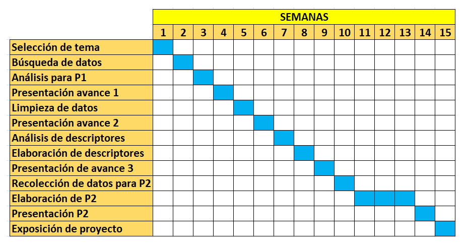

## **Contexto**

La provincia de Huamanga, ubicada en la región de Ayacucho en Perú, alberga una población significativa de niños y niñas en el rango de edad de 12 a 36 meses. Esta etapa temprana de la vida es crítica para el desarrollo físico y cognitivo óptimo de los niños y establece las bases para su salud y bienestar en el futuro. Sin embargo, diversos factores económicos y sociales influyen en el estado nutricional de los niños. Desde el punto de vista económico, Huamanga se caracteriza por tener una tasa de pobreza alta, lo que limita el acceso a alimentos nutritivos y servicios de salud adecuados. Además, es importante considerar los programas sociales existentes en la provincia de Huamanga, como SIS ,Qali Warma y Juntos, que tienen como objetivo brindar apoyo y asistencia a las familias en situación de vulnerabilidad. Estos programas pueden desempeñar un papel importante en el estado nutricional de los niños y niñas, ya sea a través de la provisión de alimentos o el acceso a servicios de salud y educación. Comprender este contexto es fundamental para diseñar intervenciones efectivas y estrategias de mejora del estado nutricional en esta población.

# **Datos**

## **Proceso de recolección de datos**

Para la recolección de datos, se consultó al docente las fuentes de las cuales podríamos extraer una base de datos necesario para nuestro tema, debido a que se decidió trabajar con una base de datos. El motivo por el cuál elegimos una base de datos fue para obtener más datos confiables y además requiere menos tiempo en comparación a una encuesta.

## **Población, muestra y muestreo**

**Población:** Los niños del departamento de Ayacucho.

**Unidad muestral:** Niños de 12 a 36 meses de edad en la provincia de Huamanga.

**Tipo de muestreo:** El tipo de muestreo es no probabilístico, debido a que la elección de los datos es por conveniencia al tener una data el cual faltan datos en algunas observaciones.

## **Variables**

| V | TV | R |
| --- | --- | --- |
| Distrito | Categórica nominal | Distritos de la provincia estudiada |
| Sexo | Categórica nominal | Sexo biológico |
| Edad | Numérica discreta | Número entero mayor igual a 12 y menor igual a 36 |
| CentroDeSalud | Categórica nominal | Centros de Salud de la provincia estudiada |
| Juntos | Categórica nominal | Programa social |
| SIS | Categórica nominal | Programa de salud |
| Qaliwarma | Categórica nominal | Programa social |
| Peso | Numérica continua | Valor decimal positivo medido en kilogramos |
| Estatura | Numérica continua | Valor decimal positivo medido en centímetros |
| PTZ | Numérica Continua | Número decimal negativo o positivo |

[output cut: 7 more lines]

## **Limpieza de base de datos**

En este caso el archivo **csv** que se descargó con el nombre de **baseD**, ya se encuentra limpio y se asignó un nombre más fácil de utilizar, que será **“D”**.

```r
D1 <- read_csv("baseD.csv")
```

```
## -------------------------------------------------------- Delimiter: "," chr
## (6): Distrito, Sexo, CentroDeSalud, Dx_PT, Dx_TE, Dx_PE dbl (13): ...1, Edad,
## Juntos, SIS, PIN, Qaliwarma, Peso, Estatura, PTZ, ZTE,...
```

```r
D<-D1
B <- D[, c(6,7,9)]
```

# **Análisis Descriptivo**

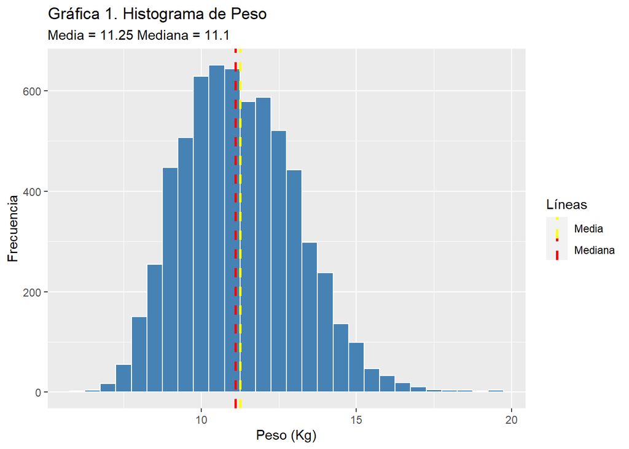

El histograma de Peso tiende a formar un campana. Además, se observa que la media y mediana de Peso es similar; es decir es aproximadamente simétrico. Por lo tanto, es necesario analizar esta variable si presenta una distribución Normal.

```r
summary(D$Peso)
```

```
##    Min. 1st Qu.  Median    Mean 3rd Qu.    Max.
##    5.80    9.90   11.10   11.25   12.50   19.70
```

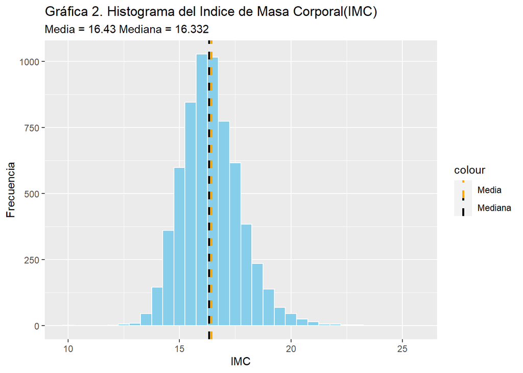

El histograma de IMC tiende a formar un cola hacia la derecha; es decir sesgada a la derecha aproximadamente. Además, se observa que la media y mediana de IMC es similar.Por lo tanto, es necesario analizar esta variable si presenta o se acerca a alguna distribución continua.

```r
summary(D$IMC)
```

```
##    Min. 1st Qu.  Median    Mean 3rd Qu.    Max.
##   9.993  15.521  16.332  16.425  17.209  25.306
```

**PTZ: Índice que compara el peso del menor con el peso esperado para su talla y permite establecer si ha ocurrido una pérdida/ganancia de peso corporal.**

Rango para Bajo Peso en PTZ = [-4.780, -2.010]

Rango para Normal en PTZ = [-1.980, 2.000]

Rango para Sobrepeso en PTZ = [2.010, 2.960]

Rango para Obesidad en PTZ =[3.020,4.540]

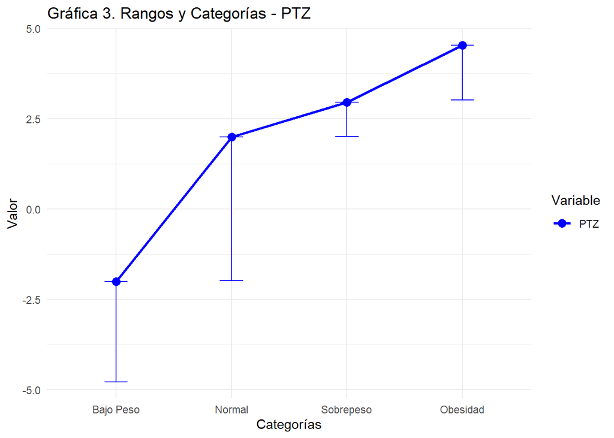

Este gráfico de puntas representa el intervalo del índice de Peso y Talla de cada categoría de Peso en un niño.

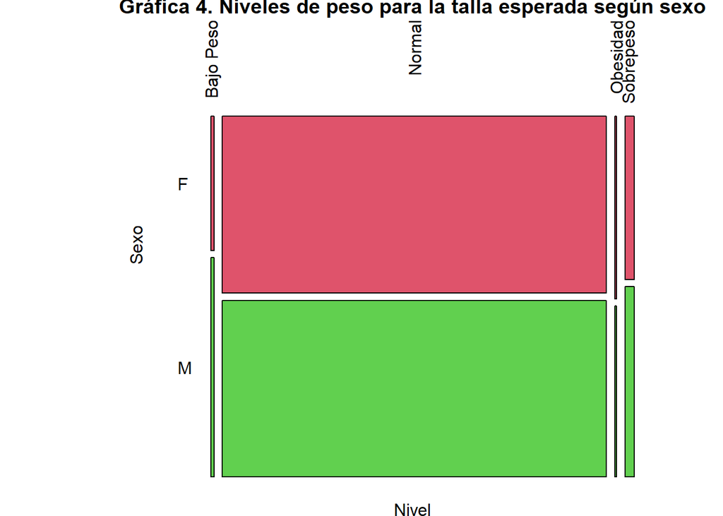

Al observar la gráfica de mosaico que representa la condición del peso de acuerdo a la talla esperada de los niños, se puede notar que la gran mayoría se encuentra en la categoría de peso normal. En contraste, las barras correspondientes a las categorías de sobrepeso, obesidad y bajo peso son mucho más bajas, lo que sugiere que estas condiciones son menos comunes en la población estudiada.

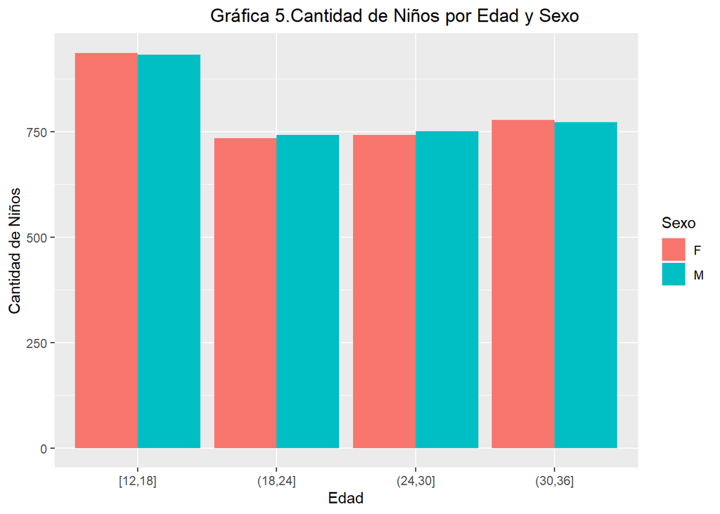

Se observa que la cantidad de niños y niñas es similar en los rangos de edades establecidos.

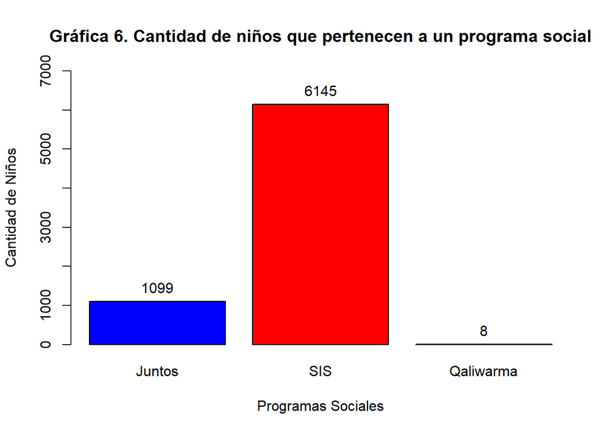

El programa social con más participación es **SIS**. En segundo lugar, el programa **Juntos** y finalmente el **Qaliwarma**.

# **Análisis Probabilístico**

## **Probabilidad empirica**

Variables ===> PTZ(DX_PT)

**PTZ: Índice que compara el peso del menor con el peso esperado para su talla y permite establecer si ha ocurrido una pérdida/ganancia de peso corporal.** **DX_PT : Diagnóstico del PTZ ( Bajo Peso, Normal, Obesidad, Sobrepeso)**

1. **Criterios de Evaluación basado en el PTZ de los niños**.

Rango para Bajo Peso en PTZ = [-4.780, -2.010]

Rango para Normal en PTZ = [-1.980, 2.000]

Rango para Sobrepeso en PTZ = [2.010, 2.960]

Rango para Obesidad en PTZ =[3.020,4.540]

```r
table(D1$Dx_PT)
```

```
##
## Bajo Peso    Normal  Obesidad Sobrepeso
##        50      6167        29       145
```

| Bajo Peso | Normal | Obesidad | Sobrepeso | Total |
| --- | --- | --- | --- | --- |
| 50 | 6167 | 29 | 145 | 6391 |

**Experimento A:** Se selecciona aleatoriamente a un niño del estudio y se observa su índice que compara el peso del menor con el peso esperado para su talla.

Espacio Muestral:
$$\Omega = \{ Bajo Peso,
Normal ,Obesidad, Sobrepeso\}$$

**Eventos Atómicos** A1 = Seleccionar a un niño que tenga un diagnóstico de Bajo Peso. A2 = Seleccionar a un niño que tenga un diagnóstico Normal. A3 = Seleccionar a un niño que tenga un diagnóstico de Sobrepeso. A4 = Seleccionar a un niño que tenga un diagnóstico de Obesidad.

**Probabilidades de cada Evento** Se utiliza la siguiente forma *Enfoque clásico*
$$P(A) = \frac{N(A)}{N(\Omega)}$$
donde: **N(A):** Número de Sucesos del evento A **N(**$\Omega$):Número de sucesos del espacio muestral

*Enfoque de Frecuencia Relativa*
$$P(A) = \frac{f(A)}{n}$$
donde: **f(A)**: Frecuencia Absoluta de A **n**: Número de Observaciones

Probabilidad del evento A1:
$$P(A_1) =
\frac{50}{6391} = 0.0078$$

Probabilidad del evento A2:
$$P(A_2) =
\frac{6167}{6391} = 0.9649$$

Variable 2 ===> Programa Sociales

**Criterio** : Niños que pertenecen a algún tipo de Programa Social

```r
cbind(SIS = table(D$SIS), JUNTOS = table(D$Juntos), Qaliwarma = table(D$Qaliwarma))
```

```
##    SIS JUNTOS Qaliwarma
## 0  246   5292      6383
## 1 6145   1099         8
```

| Programa Social | SIS | JUNTOS | QALIWARMA |
| --- | --- | --- | --- |
| NO | 246 | 5292 | 6383 |
| SI | 6145 | 1099 | 8 |

**Experimento E :** Se selecciona aleatoriamente un niño del estudio y se observa en que tipo de programa social participa.

Espacio Muestral:
$$\Omega_{\text{Resultados}} = \{SIS, Juntos,
Qaliwarma\}$$
**Evento Atómicos** E1 = Seleccionar a un niño que participe en el programa social **SIS**. E2 = Seleccionar a un niño que participe en el programa social **Juntos**. E3 = Seleccionar a un niño que participe en el programa social **Qaliwarma**.

**Probabilidades - Enfoque de Frecuencia Relativa**
$$P(A) = \frac{f(E)}{n}$$
donde: **f(A)**: Frecuencia Absoluta de E: Cantidad de niños que participan en programas sociales. **n**: Número de Observaciones

Probabilidad del evento E1:
$$P(E_1) =
\frac{6145}{6391} = 0.9615$$

Probabilidad del evento E2:
$$P(E_2) =
\frac{1099}{6391} = 0.1719$$

Probabilidad del evento E3:
$$P(E_3) =
\frac{8}{6391} = 0.0012$$

## **Probabilidad condicional**

**Eventos Independientes**

Tabla de contingencia:

| EDAD | Normal | Complemento | TOTAL |
| --- | --- | --- | --- |
| [18-24[ | 1433 | 58 | 1491 |
| Complemento | 4734 | 166 | 4900 |
| **TOTAL** | 6167 | 224 | 6391 |

**EVENTOS** A <- Seleccionar a un niño que tenga un diagnostico Normal. B <- Seleccionar a un niño que tenga entre 18 y 24 meses de edad.

Verificar si los eventos A y B son independientes
$$P(A \cap B)=P(A)*P(B)$$

Probabilidad de **A**
$$P(A)
= \frac{6167}{6391} = 0.96$$

Probabilidad de **B**
$$P(B)
= \frac{1491}{6391} = 0.23$$

Probabilidad de **A intersección B**
$$P(A \cap B)=\frac{1433}{6391} = 0.22$$

Probabilidad de **A** por Probabilidad de **B**
$$P(A)*P(B)=0.96*0.23=0.22$$

Entonces se puede decir que los eventos A y B son Independientes
$$P(A \cap B)\approx{}P(A)*P(B)$$

1. ¿Cuál es la probabilidad de que el niño seleccionado aleatoriamente tenga diagnóstico normal dado que se encuentre entre 18 y 24 meses de edad?
   $$P(A/B) = P(A)$$

```r
P_A <- (6167/6391)
round(P_A,2)
```

```
## [1] 0.96
```

$$P(A/B) = 0.96$$
La probabilidad de que un niño seleccionado aleatoriamente tenga diagnostico normal dado que se encuentre entre 18 y 24 meses de edad es de 96%.

2. ¿Cuál es la probabilidad de que un niño seleccionado aleatoriamente se encuentre entre 18 y 24 meses de edad dado que tenga un diagnostico Normal?
   $$P(B/A) = P(B)$$

```r
P_B <- (1491/6391)
round(P_B,2)
```

```
## [1] 0.23
```

$$P(B/A) = 0.23$$
La probabilidad de que un niño seleccionado aleatoriamente se encuentre entre 18 y 24 meses de edad dado que tenga un diagnostico Normal es de 23%.

3. ¿Cuál es la probabilidad de que un niño seleccionado aleatoriamente se encuentre entre 18 y 24 meses de edad **o** tenga un diagnóstico Normal?
   $$P(A \cup B ) = P(A) +
   P(B) - P(A)*P(B)$$

```r
P_C<- (0.96+0.23)-(0.96*0.23)
round(P_C,2)
```

```
## [1] 0.97
```

$$P(A \cup B ) =
(0.96+0.23)-(0.96*0.23)=0.97$$
La probabilidad de que un niño seleccionado aleatoriamente se encuentre entre 18 y 24 meses de edad **o** tenga un diagnóstico Normal es de 97%.

**Eventos Dependientes**

Tabla de contingencia

|  | IMC menor al promedio | IMC mayor al promedio | TOTAL |
| --- | --- | --- | --- |
| Peso menor al promedio | 2025 | 1335 | 3360 |
| Peso mayor al promedio | 1390 | 1641 | 3031 |
| **TOTAL** | 3415 | 2976 | 6391 |

**EVENTOS**

A <- Seleccionar un niño que tenga un Peso mayor al valor promedio. B <- Seleccionar un niño que tenga un IMC mayor al valor promedio.

Verificar si los eventos A y B son dependientes.

Probabilidad de **A**
$$P(A)
= \frac{3031}{6391} = 0.47$$

Probabilidad de **B**
$$P(B)
= \frac{2976}{6391} = 0.47$$

Probabilidad de **A intersección B**
$$P(A \cap B) = \frac{1641}{6391} =
0.26$$

Probabilidad de **A** por Probabilidad de **B**
$$P(A)*P(B)=0.47*0.47=0.22$$

$$P(A \cap B) != P(A)*P(B) =>
0.26!=0.22$$
Como los valores no son iguales, entonces los eventos son dependientes.

1. ¿Cuál es la probabilidad de que el menor seleccionado presente un Peso mayor al valor promedio del peso dado que presenta un IMC mayor al valor promedio del IMC ?

Planteamos lo siguiente:
$$P(A/B) =
\frac{P(A \cap B)}{P(B)}$$
Se tiene los datos hallados anteriormente:

$$P(A \cap B) = 0.26$$
$$P(B) = \frac{2976}{6391} = 0.47$$

$$P(A/B) = \frac{0.26}{0.47} =
0.55$$

2. ¿Cuál es la probabilidad de que el menor seleccionado presenta un IMC mayor al valor promedio del IMC dado que tiene un peso mayor al valor promedio del peso?

Teorema de bayes
$$P(B/A) =
\frac{P(A/B)*P(B)}{P(A)}$$

Datos obtenidos anteriormente:

```r
Ptb <- round(2976/6391,2)
Ptb
```

```
## [1] 0.47
```

$$P(B) = \frac{2976}{6391} =
0.47$$

$$P(B/A) = \frac{0.55*0.47}{0.47} =
0.55$$
La probabilidad de seleccionar un niño que presenta un IMC mayor al valor promedio del IMC dado que tiene un peso mayor al valor promedio del peso, es del 55%.

## **Variables aleatorias discretas**

**1.Analizar una Distribución Binomial**

Criterios :

Los eventos son independientes. Cada niño de la muestra tiene una probabilidad constante de presentar sobrepeso, y el diagnóstico de un niño no afecta el diagnóstico de otros niños.

La probabilidad de éxito es constante. La probabilidad de que un niño presente sobrepeso es la misma para todos los niños de la muestra.

El tamaño de la muestra es fijo. La muestra de 6391 niños es fija.

$$X \sim B(n,p)$$
*Donde :*

p = Probabilidad de éxito n = Tamaño de la muestra

**2. Variable aleatoria**

$X$ : Número de niños de la Provincia Huamanga que presentan un diagnóstisco de Sobrepeso en el año 2022 de una muestra de 6391 niños.

**3. Identificar Parámetros**

E : Seleccionar un niño de la Provincia Huamanga que se ha diagnosticado con Sobrepeso. n : Tamaño de la población

```r
a<-nrow(filter(D,Dx_PT=="Sobrepeso"))
n<-nrow(D)
round(a/n,5)
```

```
## [1] 0.02269
```

$$P(E) : \frac{f(a)}{n} = \frac{145}{6391}
= 0.02269$$
Por lo tanto la probabilidad de éxito es : $p= 0.02269$

**4. Construir la función de masa de probabilidad**
$$dbinom(0:n,p,n)$$

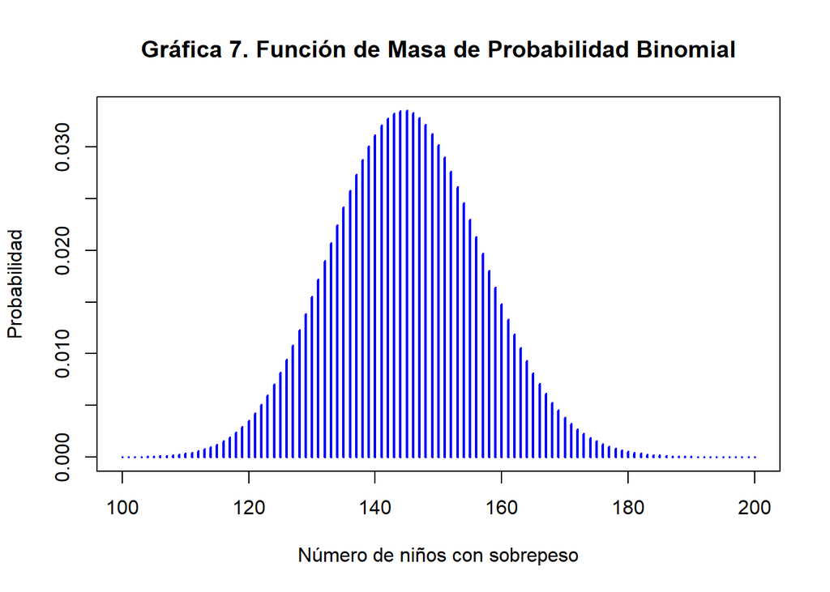

Cada bastón representa la probabilidad en una cantidad exacta de niños. La probabilidad acumulada es la unidad - **1**.

**Gráfica de los 145 niños que fueron diagnosticado con Sobrepeso**

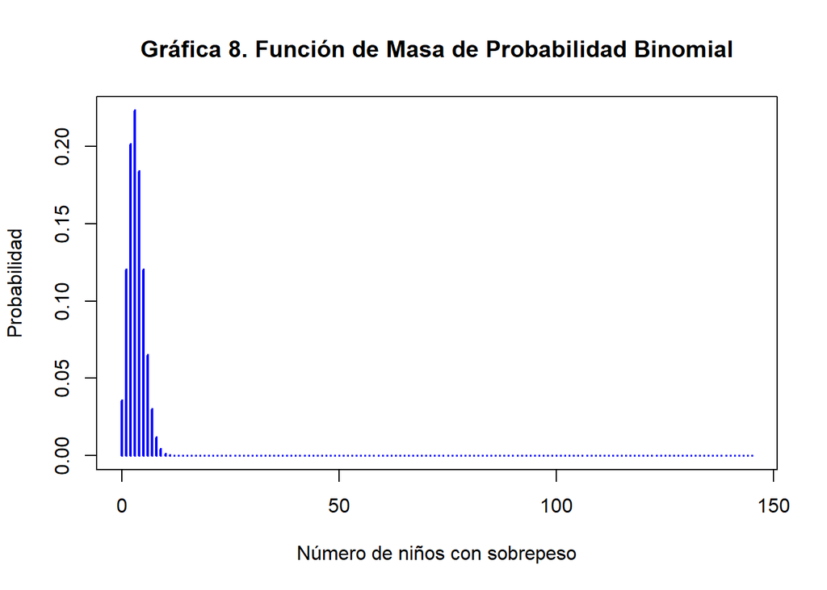

**5.Validar las Probabilidades**

Calculando el Valor esperado $E(X)$
$$E(X)=np$$
Por lo tanto $E(X)=6391*0.02269 = 145.01$

Calculando la Varianza $Var(X)$
$$Var(X)=np(1-p)$$
Por lo tanto $Var(X)=6391*0.02269*(1-0.02269)= 141.72$

Calculando la desviación estándar $sd$
$$\text{sd}
= \sqrt{\text{Var}(X)}$$
La desviación estándar $sd$ es 11.9

Calculando el coeficiente de Variabilidad
$$CV=
\frac{sd(X)}{E(X)}=\frac{11.9}{145.01}=0.082$$
El coeficiente de variabilidad $(CV)$ es 0.082 lo que indica que tiene una baja variabilidad.

**6. Casos aplicativos**

$Ejemplo 1$ Una compañía de Salud sabe que la probabilidad de identificar un niño de la Provincia Huamanga que se ha diagnosticado con Sobrepeso es igual a 2.269%. Si la compañía de Salud selecciona una muestra con reemplazo o con reposición de 6391 niños de la provincia de Huamanga.

1. ¿Cuál es la probabilidad de que exactamente 150 niños presenten Sobrepeso?

$Solución$

```r
round(dbinom(150,6391,0.02269),2)
```

```
## [1] 0.03
```

$$dbinom(150,6391,0.02269)= 0.03$$
La probabilidad de que exactamente 150 niños presenten sobrepeso es de 3%

$Ejemplo 2$ Supongamos que el Ministerio de Salud está realizando un experimento en un laboratorio para probar un nuevo medicamento. Se ha demostrado que los niños que presentan Sobrepeso tienen una tasa de éxito del 2.269% en el tratamiento de una enfermedad específica. Decides seleccionar al azar a 6391 niños que sufren de esta enfermedad y administrarles el medicamento.

2. ¿Cuál es la probabilidad de que más de 145 niños tratados con el medicamento experimenten mejoría?

```r
round(1-pbinom(145,6391,0.02269),2)
```

```
## [1] 0.48
```

$$1-pbinom(145,6391,0.02269)=
0.48$$
La probabilidad de que más de 145 niños tratados con el medicamento experimenten mejoría es de 48%

**1.Analizar una Distribución Poisson**

Criterios :

Eventos discretos y aleatorios: La distribución de Poisson se utiliza para modelar eventos discretos que ocurren de forma aleatoria en un intervalo de tiempo o espacio. En este caso,el número de niños con sobrepeso en la muestra se ajuste a esta descripción.

Tasa promedio constante: La distribución de Poisson asume que la tasa promedio de eventos es constante en el intervalo de tiempo o espacio considerado. En este caso, la tasa promedio sería el número promedio de niños con sobrepeso por niño en la muestra.

$$X \sim P(\lambda)$$

**2. Variable aleatoria** : $X$ : Número de niños de la Provincia Huamanga que presentan un diagnóstisco de Sobrepeso en el año 2022 de una muestra de 6391 niños.

**3. Identificar Parámetros** $\lambda$ = Cantidad promedio de niños con sobrepeso por niño en la muestra.

```r
a<-nrow(filter(D,Dx_PT=="Sobrepeso"))
n<-nrow(D)
round(a/n,5)
```

```
## [1] 0.02269
```

$$\lambda : \frac{f(a)}{n} =
\frac{145}{6391} = 0.02269$$
Por lo tanto la tasa promedio de niños con sobrepeso por niño en la muestra : $p= 0.02269$

**4. Construir la función de masa de probabilidad**
$$dpois(0:n,\lambda)$$

[figure not shown]

Cada bastón representa la probabilidad en una cantidad exacta de niños. La probabilidad acumulada es la unidad - **1**.

**5.Validar las Probabilidadess**

Valor esperado $E(X)$
$$E(X)=\lambda$$
Por lo tanto $E(X)=0.02269$

Varianza $Var(X)$
$$Var(X)=\lambda$$
Por lo tanto $Var(X)=0.02269$

Desviación estándar $sd$
$$\text{sd} = \sqrt{\text{Var}(X)} =
\sqrt{0.02269}$$
La desviación estándar $sd$ es 0.150632

Calculando el coeficiente de Variabilidad
$$CV= \frac{E(X)}{sd(X)} =
\frac{0.02269}{0.150632}$$
El coeficiente de variabilidad $(CV)$ es 0.1506

**6. Casos Aplicativos**

$Ejemplo 1$ Luego de una Charla de Nutrición por parte de ESSALUD en la Provincia de Huamanga. Se propone calcular la probabilidad de que haya 3 niños con Sobrepeso (k=3) sabiendo que la la tasa promedio de niños con sobrepeso en la Provincia Huamanga en el año 2022, basada en la muestra de 6391 niños, es de 2.2269% niños con sobrepeso por niño.

```r
dpois(3,0.02269)
```

```
## [1] 1.90326e-06
```

```r
ppois(11,0.02269) -ppois(3,0.02269)
```

```
## [1] 1.084542e-08
```

## **Variables aleatorias continuas**

**Distribución Normal**

**1.Identificar Gráficamente**

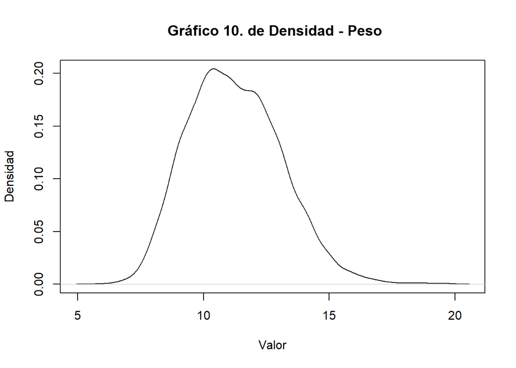

De acuerdo al gráfico 1, la variable peso tiende a formar un campana en su histograma.

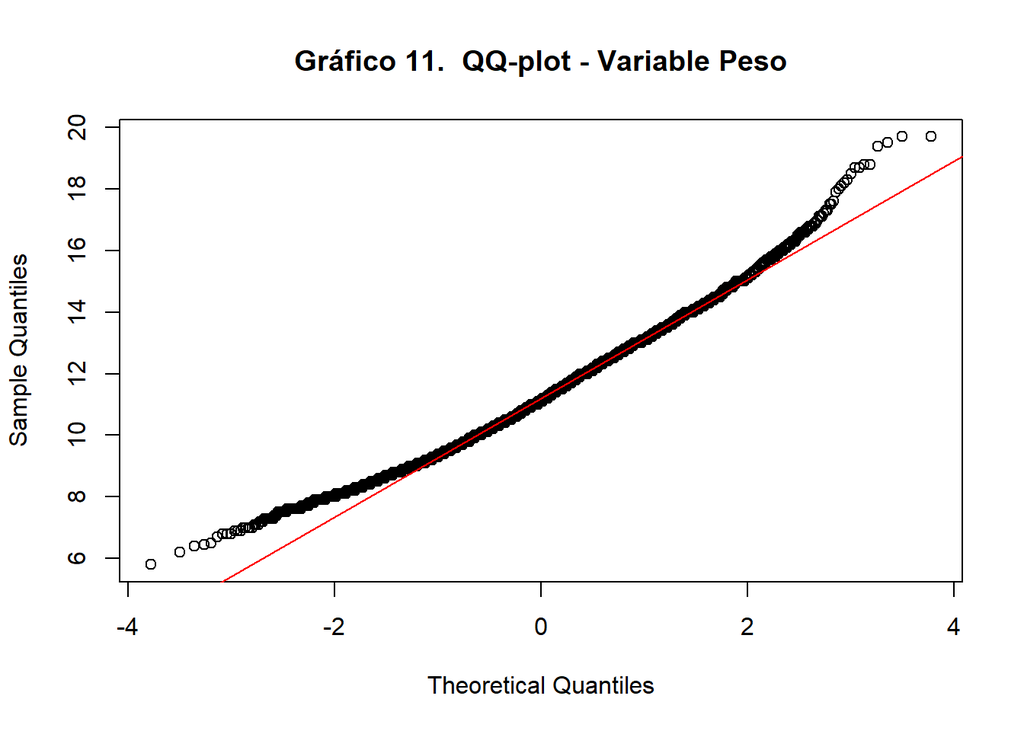

Los puntos se acercan a linealizarse a la recta - Por lo tanto, se acerca a una distribución Normal.

**2.Validar**

$$\bar{X}\approx{Me}$$

```r
mean(D$Peso)
```

```
## [1] 11.24681
```

```r
median(D$Peso)
```

```
## [1] 11.1
```

```r
asimetría <- skewness(D$Peso)
# Imprimir resultados
cat("Asimetría: ", asimetría, "\n")
```

```
## Asimetría:  0.4065988
```

$$Var(X)= sd^2$$

```r
Var(D$Peso)
```

```
## [1] 3.433598
```

```r
sd(D$Peso)^2
```

```
## [1] 3.433598
```

$$E(X) = \bar{X}$$

```r
mean(D$Peso)
```

```
## [1] 11.24681
```

Se considera a la variable continua Peso como una posible distribución normal.

**3.Parámetros**
$$X \sim
N(\mu,\sigma)$$
Donde:

$$E(X)=\mu$$
$$Var(X)=\sigma^2$$

$\mu$ $\bar X$ $\sigma= sd$

**4. Casos Aplicativos**

$Ejemplo 1$

Un grupo de estudiantes de UTEC han realizado un estudio sobre el peso de niños y niñas de 12 a 36 meses en la provincia de Huamanga, Perú, durante el año 2022. Los datos recopilados de 6391 niños y niñas indican que la media de los pesos es de 11.24681 y la varianza es de 3.433598.

1. Si se selecciona un niño al azar ¿Cuál es la probabilidad de que pese menos de 10 kg?

$$(P(X<10)=P(X≤10))$$

```r
round(pnorm(10, mean(D$Peso), var(D$Peso)),4)
```

```
## [1] 0.3583
```

2. ¿Cuál es la probabilidad de que pese por lo menos 8 kg?

```r
round(1-pnorm(8, mean(D$Peso), var(D$Peso)),2)
```

```
## [1] 0.83
```

$Ejemplo 2$

1. ¿Cuál es la probabilidad de que los niños pesen más de 10 y menos de 19 kg?
   $$P(X≤19)-P(X≤10)=P(X<19)-P(X<10)$$

```r
mu <- 11.24681
sigma <- 1.852997
pnorm(19, mu, sigma) - pnorm(10, mu, sigma)
```

```
## [1] 0.7494679
```

**Distribución Gamma**

**1. Verificar si está sesgada hacia la derecha**

Criterios

**Variables positivas:** La distribución gamma se utiliza para modelar variables que toman valores positivos. Por lo tanto, es importante que la variable en estudio no tenga valores negativos. **Asimetría positiva:** La distribución gamma es asimétrica y sesgada hacia la derecha. Esto significa que la cola de la distribución se extiende hacia los valores más altos. Por lo tanto, si tus datos muestran una asimetría positiva, es posible que una distribución gamma sea apropiada. **Cola larga:** La distribución gamma tiene una cola larga hacia los valores más altos. Esto significa que la probabilidad de observar valores extremos o inusualmente altos es relativamente alta en comparación con otras distribuciones, como la distribución normal.

**Identificar Gráficamente**

[figure not shown]

De acuerdo a la gráfica 2.El histograma del IMC presenta un desplazamiento hacia la cola derecha del gráfico.

**2.Validar**

```r
round(mean(D$IMC),3)
```

```
## [1] 16.425
```

```r
round(median(D$IMC),3)
```

```
## [1] 16.332
```

```r
asimetría <- skewness(D$Peso)
cat("Asimetría: ", asimetría, "\n")
```

```
## Asimetría:  0.4065988
```

**3.Parámetros**

$$X\sim Gamma(\alpha,\beta)$$

**4.Parámetro de forma**

```r
fit <- fitdistr(D$IMC, "gamma")
shape <- fit$estimate["shape"]
print(shape)
```

```
##    shape
## 147.7239
```

**5.Parámetro de Escala**

```r
fit <- fitdistr(D$IMC, "gamma")
scale <- 1 / fit$estimate["rate"]
print(scale)
```

```
##      rate
## 0.1111888
```

Por lo tanto
$$\alpha=147.72 ...
\beta=0.11$$
Donde $\alpha=Parámetro de Forma$ $\beta=Parámetro de Escala$

Valor esperado :
$$E(X)=\alpha\beta$$
Por lo tanto $E(X)=147.72*0.11 = 16.24924$

```r
mean(D$IMC)
```

```
## [1] 16.42526
```

Varianza :
$$Var(X)=\alpha\beta^2$$
Por lo tanto $Var(X)=147.72*0.11^2=1.7874$

```r
var(D$IMC)
```

```
## [1] 1.826306
```

**6.Casos Aplicativos**

$Ejemplo 1$

Se realiza un estudio de salud en una población de niños y está interesado en analizar la probabilidad de que un niños tenga un IMC (Índice de Masa Corporal) en un cierto rango. Calcular la probabilidad de que un niño seleccionado al azar de esta población tenga un IMC en el rango de 20 a 25.Basándote en tus datos y análisis, haz estimado que los parámetros de forma y escala de la distribución gamma son aproximadamente 147.72 y 0.111, respectivamente.

$Solución$
$$X \sim Gamma(\alpha=147.72,\beta=0.111)$$
pide $P(20<=X<25)$
$$pgamma(25,\alpha,\beta^-1)
-pgamma(20,\alpha,\beta^-1)$$

```r
round(pgamma(25,147.72,1/0.111)-pgamma(20,147.72,1/0.111),4)
```

```
## [1] 0.0058
```

Luego, calcular la Probabilidad de que un niño seleccionado al azar de esta población tenga un IMC no mayor a 20, Si se mantiene constante los parámetros del ítem anterior.

```r
round(pgamma(20,147.72,1/0.111),4)
```

```
## [1] 0.9942
```

# **Conclusiones**

La cantidad total de niños que participan en los programas sociales Juntos, SIS Y Qaliwarma son 1099, 6145 y 8 respectivamente. Donde el programa SIS resalta por la mayor cantidad de participación tanto de niñas y niños.

El estado nutricional de niños se encuentran en la categoría de peso normal. En contraste, las categorías de sobrepeso, obesidad y bajo peso son mucho más bajas.

Se realizó las probabilidades empíricas y condicionales de diferentes eventos atómicos contextualizados en el estudio del Estado nutricional de la Provincia de Huamanga 2022.

Se identificó dos variables aleatorias discretas, así como la distribución de probabilidad que les representa y el cálculo de diversos casos aplicativos. Además, se clasificó a dos variables continuas en una posible y cercana distribución probabilística de acuerdo a los parámetros identificados, así como ejemplos aplicativos para el cálculo de sus probabilidades.